# Big Data Academy Módulo R

# 1 Prefácio

Esta apostila está estruturada considerando três etapas: a apresentação do ambiente R, a sua linguagem de programação, considerando aspectos estruturais da linguagem, e por fim a apresentação do R com foco na rotina de análise da Ciência de Dados.

# 2 O Ambiente R

## 2.1 O que é e por que usar?

O R é uma linguagem de programação interpretada, além de um ambiente de software gratuito. Criado em 1995, no departamento de Estatística da Universidade de Auckland - Nova Zelândia, por Ross Ihaka e Robert Gentleman. Foi batizado como “R”, tanto pelo nome de seus criadores, quanto para fazer uma provocação à linguagem S, visto ser uma implementação desta.

O ambiente R é disponibilizado em diferentes tipos de plataformas, oferecendo um vasto leque de funcionalidades, bases de dados, e integrações com outras linguagens de programação, tudo acessível via bibliotecas. Tais bibliotecas podem ser instaladas ou desenvolvidas pelo próprio usuário, neste último caso permitindo a disponibilização em repositórios públicos para o acesso dos demais usuários. Em termos de suporte, o R possui uma comunidade extremamente ativa, engajada no aprimoramento direto da ferramenta, desenvolvimento de novas bibliotecas, e suporte gratuito dos usuários, por meio de fóruns online, encontros presenciais e materiais dos mais diferentes tipos.

O R é descrito no seu site oficial (https://www.r-project.org/) como um ambiente para computação estatística e gráficos. Isto se deve a sua larga, coerente e integrada coleção de recursos para todo o workflow da análise de dados (leitura, limpeza, visualização, modelagem e comunicação de dados). Tendo ainda que se trata de um ambiente muito utilizado na academia, fazendo com que muitas metodologias novas sejam primeiramente implementadas no R. Somando tais características à amplitude e gratuidade da ferramenta, temos que o R atualmente é um dos principais ambientes para trabalhar com análise de dados.

## 2.2 Da Instalação ao Hello World

Para instalar o R o primeiro passo é entrar na página oficial do ‘The R Project for Statistical Computing’ (http://www.r-project.org/), página que incluí desde tutoriais e listas de mailing até a lista de eventos de interesse e o mapeamento de upgrades e bugs. E na sessão Downloads, opção CRAN, escolha o servidor do local mais próximo ao qual você se encontra, ou vá direto para https://cloud.r-project.org, escolha o seu sistema operacional (utilizaremos o Windows como referência), o subdiretório “base”, e então fazer o download da versão mais recente do programa:

[figure not shown]

R: Download.

Click duas vezes no arquivo de instalação baixado, selecione o idioma de sua preferência, e então você estará no Assistente de Instalação. Caso você não seja administrador, na tela em que especifica a pasta em que o programa será instalado, é necessário alterá-lo para um repositório dentro do seu usuário. No mais, basta seguir o padrão de instalação do Windows até a conclusão da instalação. Pronto! Tendo o R na sua máquina, você pode acessa-lo via ícone na área de trabalho, busca do Windows, ou pelo executável que se encontra na pasta em que o R foi instalado. E ao digitar `"Hello World"` na janela “R Console” temos:

[figure not shown]

R: Hello World.

Via point-and-click temos opções que vão desde mudanças de diretórios até a instalação de bibliotecas. Porém, por se tratar de um interpretador, tais opções são limitadas, e temos poucos recursos em termos de usabilidade. Como alternativa podemos trabalhar em Ambientes de Desenvolvimento Integrados, ou IDEs, como são mais conhecidas (*Integrated Development Environment*). A mais difundida no caso do R é o **RStudio**:

### 2.2.1 A IDE RStudio

O RStudio é de uma IDE do R, amplamente difundida dado os seus muitos recursos, conforme poderemos vivenciar ao longo desta apostila. Para fazer o download do RStudio entre na página oficial do RStudio (https://www.rstudio.com/), na opção ‘Download’ RStudio, após passar pela descrição das opções disponíveis do RStudio, você encontrará a lista de instaladores organizados segundo os sistemas operacionais e processadores compatíveis:

[figure not shown]

RStudio: Download.

Caso você tenha acesso de administrador baixe a versão correspondente ao seu ambiente a partir da lista de *Installers for Supported Platforms*, abra o instalador e siga as instruções, até a conclusão da instalação. Caso não, faça o download a partir da lista *Zip/Tarballs*, e extraia os arquivos para a pasta desejada. Entre na pasta extraída e procure o diretório `\bin`, nele você irá encontrar um arquivo chamado rstudio, clique duas vezes e você estará no RStudio. E, similarmente ao caso anterior, ao digitar `"Hello World"` na janela Console, teremos:

[figure not shown]

RStudio: Hello World.

Para facilitar futuros acessos é recomendável fixar o programa na barra de tarefas, criar um atalho na área de trabalho, ou o que você julgar mais fácil para a sua utilização. Tanto o R quanto o RStudio são atualizados com frequência, de modo que é recomendado fazer updates regulares.

## 2.3 Tour pelo RStudio

O RStudio possui uma série de recursos que facilitam a utilização do R, uma delas é a própria interface, que apresenta algumas opções de painéis. Os dois principais são:

- **Console**: painel onde os comandos são executados interativamente, permitindo opções como autocompletar e consultas por meio da tecla ‘Tab’, ou o acesso aos comandos já digitados via a tecla ‘Seta para cima’;
- **Source**: onde são abertos os scripts do R, ou seja, onde você irá escrever o código, que só será enviado para o Console quando executado. Para abrir um script podemos ir via point-and-click ‘File > New File > R Script’ ou pelo atalho Ctrl+Shift+N;

[figure not shown]

RStudio: Painéis.

Adicionalmente temos também:

- **Environment**: listagem dos objetos definidos ao longo da sessão;
- **Files**: acesso às pastas e arquivos do computador;
- **Help**: menu de ajuda e visualização das documentações consultadas;
- **History**: consulta do histórico de comandos;
- **Packages**: gerenciamento das bibliotecas instaladas;
- **Plots**: visualização dos gráficos gerados; e
- **Viewer**: visualização dos relatórios e aplicativos gerados.

Todos os painéis possuem uma série de funcionalidades próprias, sendo interessante que, conforme avance na sua utilização do R, volte a explorar tais opções. A mesma premissa vale para a barra de ferramentas do RStudio, onde é possível encontrar desde recursos de codificação, como indentação de linhas, até questões de Debug ou personalização da ferramenta, via ‘Tools > Global Options’:

[figure not shown]

RStudio: Layout dos Painéis.

# 3 Programação em R

## 3.1 O R como calculadora

Para a familiarização tanto com a interface básica do R, quanto com a sua IDE RStudio, vamos executar alguns comandos básicos no Console do R:

```r
#soma (o separador decimal no R é o ponto)
  1 + 1.5
  #> [1] 2.5
```

Note que no Console do R os textos precedidos por `#` são comentários, enquanto que os antecedidos por `>` caracterizam resultados - neste material os resultados serão precedidos por `#>`, visando diferencia-lo dos comandos:

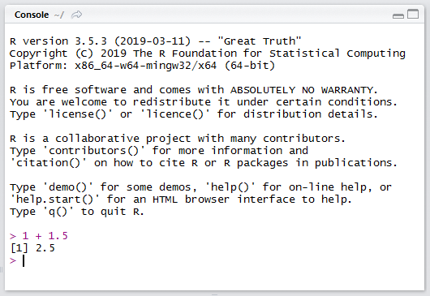

RStudio: Calculadora.

Seguem mais algumas operações aritméticas básicas:

```r
#subtração
  7 - 2
  #> [1] 5
#divisão
  9 / 3
  #> [1] 3
#multiplicação
  100 * 10
  #> [1] 1000
#potência
  2^4
  #> [1] 16
#resto da divisão de 10 por 3
  10 %% 3
  #> [1] 1
# parte inteira da divisão de 10 por 3
  10 %/% 3
  #> [1] 3
```

Em todos os casos o resultado foi precedido por `[1]`, o que faz referência à quantidade de elementos do resultado. Voltaremos a este ponto na seção de Vetores atômicos.

O R permite ampliar as equações mantendo a notação básica de operações algébricas, como a aplicação hierárquica de parênteses ou de operações. Vale ressaltar que somente os parênteses podem ser utilizados nas expressões matemáticas, visto que as chaves `{}` e os colchetes `[]` possuem finalidades próprias (bloco de *statements* e *subsetting* de dados, respectivamente):

```r
#equação ok
  (2 * ( 2 * ( 2 * (4-3))))
#equação não ok
  (2 * { 2 * [ 2 * (4-3)]})
  #> Error: <text>:4:14: '[' inesperado
  #> 3: #equação não ok
  #> 4:   (2 * { 2 * [
  #>                 ^
```

Podemos também trabalhar com operadores lógicos no R, tendo como saída `TRUE` ou `FALSE`. Note que podemos escrever dois comandos em uma única linha utilizando o símbolo `;` entre eles:

```r
#maior/menor
  1 < 0 ; 1 > 0
  #> [1] FALSE
  #> [1] TRUE
#menor/maior ou igual
  1 <= 1 ; 1 >= 1
  #> [1] TRUE
  #> [1] TRUE
#igual/diferente
  1 == 1 ; 1 != 1
  #> [1] TRUE
  #> [1] FALSE
```

Uma outra forma de executar uma expressão no R, é escrever o código no Editor (*Source*, ou ainda *R Script*), e envia-lo para a execução no Console por meio do atalho ‘Ctrl + Enter’ ou pelo botão ‘Run’ do RStudio.

No caso de digitarmos um comando incompleto no Console, como `8 ==` ou `6 +` seguidos de ‘Enter’, o R mostrará o símbolo `+`, o que não tem relação com o símbolo aritmético, mas sim que o R está aguardando os próximos comandos. Para iniciar um novo comando, desconsiderando comandos parciais anteriores, basta pressionar a tecla ‘Esc’. Adicionalmente, no caso de comandos que o R não reconheça, ele retornará uma mensagem de erro, mas basta digitar o comando desejado na sequência:

```r
#erro
  3 % 9
  #> Error: <text>:2:5: unexpected input
  #> 1: #erro
  #> 2:   3 % 9
  #>        ^
```

> Para resgatar algum comando já digitado no Console, você pode utilizar a tecla ‘seta para cima’.

## 3.2 Aplicando funções

Assim como em muitas linguagens de programação, uma função no R é de um conjunto de instruções organizadas visando executar uma tarefa. E nesta linguagem funções possuem um papel fundamental, visto não só há muitas opções disponíveis via instalação de bibliotecas, mas também as funções *built-in*, ou seja, funções já embutidas na sua instalação básica. Considerando apenas tais funções, podemos fazer desde cálculos aritméticos e leitura de dados, até tabelas, gráficos e modelos estatísticos.

O nome de tais funções no R são, em geral, intuitivos, como a função `exp()` por exemplo, que calcula o exponencial de um número:

```r
#aplicando a função exponencial ao número 1
  exp(1)
  #> [1] 2.718282
#podemos ver o código da função ao digitar a função sem os parênteses
  exp
  #> function (x)  .Primitive("exp")
```

Uma das funções mais importantes no R é a função `help()`, ou ainda `?`, o seu operador equivalente. Pois por meio desta função temos acesso à documentação referente ao objeto que estivermos consultando - `help(função_desejada)` ou `?função_desejada`. Com isto temos acesso a informações como: descrição do objeto consultado, possibilidades de alterações, funções relacionadas, exemplos, entre outros. Consultando o help para a função `log` por exemplo, vemos que é possível mudar a base segundo a qual o logaritmo é computado, e como fazer isso:

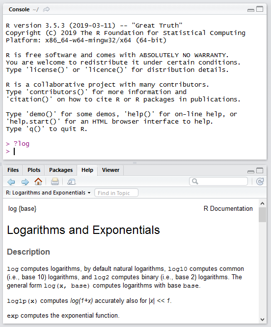

RStudio: Help.

```r
#por default o log é calculado na base exponencial
  log(10)
  #> [1] 2.302585

#de modo que o resultado não é alterado mesmo se explicitarmos o argumento 'base'
  log(10, base = exp(1))
  #> [1] 2.302585

#mas podemos altera-lo para qualquer número positivo, como a base 10 por exemplo
  log(10, base = 10)
  #> [1] 1
```

Note que não foi necessário especificar o nome do primeiro argumento da função em nenhum dos casos (`log(x=10)`). Isto porque no caso de não especificarmos os nomes dos argumentos, o R assume a lógica de posições. Tal prática não é recomendada nos casos em que utilizamos parâmetros não obrigatórios (como foi o caso do argumento `base`), ou para funções que possuem muitos argumentos.

No caso de consultas que envolvam objetos com caracteres especiais, é necessário que o texto esteja entre crases. Para consultar a documentação do comando `?`, por exemplo, precisamos digitar `` ?`?` ``. No R podemos também obter ajuda considerando tópicos de modo mais geral, por meio das funções `help.search()` e `??`.

> A função `builtins()` retorna todas as funções *built-in* disponíveis no R.

## 3.3 Criando objetos

Objetos no R são elementos que podem ser armazenados em variáveis - isto vale para dados, funções, símbolos e até expressões. Podemos criar objetos utilizando o sinal de `<-` ou `=`, para atribuições da direita para a esquerda, ou `->` para atribuições da esquerda para a direita. A recomendação é trabalhar com `<-` para atribuições de objetos, e `=` para a especificação de parâmetros, visto as características de cada um dos operadores. Existem ainda os operadores `<<-` e `->>`, que são usualmente utilizados no contexto de funções, quando há o interesse em trabalhar com objetos definidos globalmente - voltaremos neste tema no capítulo Criando funções - para mais detalhes consulte o help deste operador `` ?`<<-` ``.

Objetos podem ser nomeados com letras, números, e os símbolos `.` e `_`, desde que o nome não seja iniciado com números ou com um símbolo imediatamente seguido por um número. Adicionalmente, o R é uma linguagem sensível ao caso (*case sensitive*) e, portanto, diferencia letras maiúsculas e minúsculas:

```r
#síntaxe: letras minúsculas
  objeto <- 1 #da direita para a esquerda (RECOMENDADO)

#síntaxe: letras minúsculas com a primeira letra maiúscula
  Objeto =  2 #da direita para a esquerda

#síntaxe: letras minúsculas, símbolo e número
  3 -> objeto_1 #da esquerda para a direita
```

No R existem alguns nomes reservados para representar os seguintes casos especiais:

- **NA** (*Not Available*): uma constante lógica utilizada para representar dados faltantes, porém podendo ser também definido qualquer um dos tipos de dados descritos na próxima seção (exceto *raw*). Equivalente ao `NULL` das linguagens SQL e SAS.
- **NaN** (*Not a Number*): objeto lógico representando indefinições matemáticas, como log de números negativos.
- **Inf** (Infinito): conceito matemático (positivo ou negativo).
- **NULL**: representa a ausência de informação, utilizada como retorno de funções cujos valores são indefinidos.

Podemos utilizar as funções com o prefixo `is.` para testar se um objeto é um destes valores:

```r
  is.na(NA)
  #> [1] TRUE
  is.nan(NaN)
  #> [1] TRUE
  is.infinite(Inf); is.infinite(-Inf)
  #> [1] TRUE
  #> [1] TRUE
  is.null(NA)
  #> [1] FALSE
```

Apesar da relativa similaridade entre as definições dadas, as diferenças não só existem como também podem ser observadas na prática, como por exemplo:

```r
#exemplos
  #NULL possui tamanho zero, diferentemente das demais:
  length(NULL)
  #> [1] 0
  length(NaN); length(NA); length(Inf)
  #> [1] 1
  #> [1] 1
  #> [1] 1

  #Inf vs NaN
  pi / 0
  #> [1] Inf
  0 / 0
  #> [1] NaN

  #NA: informação de dado faltante e do tipo de objeto
  is.nan(as.character(NaN))
  #> [1] FALSE
  is.na(as.character(NA))
  #> [1] TRUE
  #tipos de objeto serão discutidos no próximo capítulo
```

Visto a relevância de tais objetos, estes não podem ser reescritos. Diferentemente de outras constantes, também pré definidas:

```r
#não conseguimos redefinir
  NA <- 0
  #> Error in NA <- 0: lado esquerdo da atribuição inválida (do_set)

#enquanto que para constantes pré existentes como:
  pi #ou
  #> [1] 3.141593
  letters
  #>  [1] "a" "b" "c" "d" "e" "f" "g" "h" "i" "j" "k" "l" "m" "n" "o" "p" "q"
  #> [18] "r" "s" "t" "u" "v" "w" "x" "y" "z"

  pi <- 0; letters <- 1
  pi; letters
  #> [1] 0
  #> [1] 1
```

Ao criar objetos passamos a ter a informação que estes carregam salvos na memória, e podemos chama-los a qualquer momento. Assim, sempre que o R encontrar algum destes objetos, ele irá substituí-lo pelos valores armazenados, inclusive aplicando em funções:

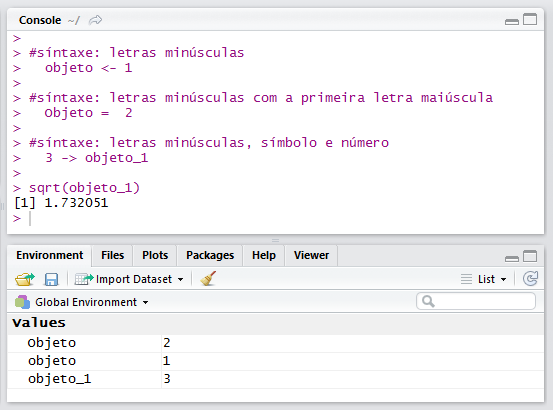

RStudio: Objetos.

Além de criar objetos atribuindo elementos diretamente a eles, podemos fazer a partir de operações entre elementos, entre objetos e como resultados de funções. Adicionalmente, para excluirmos um objeto, podemos utilizar a função `rm(nome_do objeto)`, seguido de `gc()`, para garantir a rápida liberação da referida memória:

```r
#atribuindo um elemento diretamente
  a <- 3; a
  #> [1] 3
#resultado de operações entre elementos
  b <- 5 + a; b
  #> [1] 8
#excluindo o objeto a
  rm(a); a
  #> Error in eval(expr, envir, enclos): objeto 'a' não encontrado

#operações entre outros objetos
  c <-  b * (-1); c
  #> [1] -8
#resultado da aplicação de funções
  d <- abs(c); d
  #> [1] 8
```

É possível trabalhar com objetos nomeados com sintaxes não padrão no R, ou seja, nomes que contenham espaços ou caracteres especiais. Porém, para tal, é necessário que o nome do objeto esteja entre aspas, inclusive ao aplica-lo em alguma função. De modo que, sempre que possível, é interessante que tal padrão seja evitado:

```r
#definindo o objeto com sintaxe inválida
  `1¨ objeto c/ $int@xe que $&ria #inva!ida for@ da$ a$pa$` <- 6

#aplicando-o em uma função (log na base 10)
  log10(`1¨ objeto c/ $int@xe que $&ria #inva!ida for@ da$ a$pa$`)
  #> [1] 0.7781513
```

Para listar todos os objetos disponíveis na sessão podemos utilizar a função `ls()`, enquanto que para excluir algum destes objetos temos a função `rm(nome_do_objeto)`, ou ainda para apagar todos os objetos `rm(list=ls())`.

> Para inserir o símbolo de atribuição `<-` no RStudio podemos utilizar o atalho `'alt + -'`.

## 3.4 Entendendo dados

Para tirar maior proveito da linguagem R é importante entender os diferentes tipos e estruturas de dados disponíveis. Para tal, vamos primeiramente entender sobre os tipos de dados:

### 3.4.1 Tipos de dados

No R existem seis tipos de dados, que basicamente indicam como os objetos são armazenados (*low-level*):

- **character**, textos ou strings: `"a"` ou `"isto é um teste"`
- **numeric** (ou **double**), valores decimais: `6` ou `19.4`
- **integer**, números naturais: `2L` ou `0L` (o `L` diz para o R armazenar o objeto como inteiro)
- **logical**, valores booleanos: `TRUE` e `FALSE`
- **complex**, números complexos: `1+4i` ou `1+3i`
- **raw**, bytes: `0a` ou `c8`

Para verificar qual é o tipo de armazenamento de um objeto, podemos utilizar a função `typeof()`. A função `class()` pode também ser utilizada, porém, visto que esta trabalha com a lógica hierárquica de classes da programação orientada a objetos, o resultado só será o mesmo do `typeof()` quando o objeto tiver a estrutura mais básica do R - vetores atômicos. Podemos também utilizar as funções `is.` e `as.` para testar e converter objetos, respectivamente:

```r
#definindo um objeto
  x <- 1
#o objeto é um inteiro?
  is.integer(x)
  #> [1] FALSE
#conferindo o tipo do objeto (double e numeric são sinônimos no R)
  typeof(x) ; class(x)
  #> [1] "double"
  #> [1] "numeric"
#trasformando 'x' em um texto, e redefinindo o objeto
  x <- as.character(x)
#conferindo novamente o tipo do objeto
  class(x)
  #> [1] "character"
```

Tais definições são importantes pois algumas funções só farão sentido para determinados tipos de dados. Por exemplo: considerando o objeto `x` do exemplo acima, inicialmente, quando se tratava de um tipo numérico, fazia sentido aplicarmos funções aritméticas, enquanto que para o `x` final, armazenado como texto:

```r
#tentativa de cálculo com um objeto de texto
  log(x)
  #> Error in log(x): non-numeric argument to mathematical function
```

Uma característica do armazenamento de objetos no R, é que eles respeitam a seguinte hierarquia de coerção: character > complex > numeric > integer > logical > raw. Ou seja, se tentarmos colocar tipos diferentes de objetos em um mesmo vetor atômico - estrutura discutida na próxima seção - o R irá modificar o tipo dos objetos de modo que todos passem a pertencer à mesma classe.

Tendo que objetos complexos e raw são pouco usuais, nos limitaremos a discutir: character, numeric, integer e logical.